# Making Sense of Unstructured Data Project

### This analysis of a retail company's customer data will help them better understand the different types of customers they have. By using clustering techniques to group similar customers together based on their demographics, spending habits, and how they respond to marketing campaigns, this project will identify distinct customer segments and give practical recommendations for how the company could target each group more effectively. First we will begin by analyzing the data to understand what we're working with, then we will explore different clustering approaches to find meaningful patterns in order to suggest specific marketing strategies for each customer group. The insights from this analysis will help the company's marketing team develop more personalized campaigns, improve customer retention, and make better decisions about where to allocate resources.

# Import necessary libraries

```python
import pandas as pd
import numpy as np
import matplotlib.pyplot as plt
import seaborn as sns

from sklearn.preprocessing import StandardScaler
from sklearn.cluster import KMeans, AgglomerativeClustering
from sklearn.decomposition import PCA
from sklearn.metrics import silhouette_score, adjusted_rand_score
from scipy.cluster.hierarchy import dendrogram, linkage

import warnings
warnings.filterwarnings('ignore')

plt.style.use('seaborn-v0_8')
plt.rcParams['figure.figsize'] = (10, 6)
sns.set_palette('Set2')
```

# upload dataset

```python
from google.colab import files
import io
uploaded = files.upload()
data = pd.read_csv(io.BytesIO(uploaded[next(iter(uploaded))]), sep="\t")
print(f"Loaded dataset with {data.shape[0]} rows and {data.shape[1]} columns")
print(data.head(3))
```

Upload widget is only available when the cell has been executed in the current browser session. Please rerun this cell to enable.

```
Saving Customer_Personality_Segmentation.csv to Customer_Personality_Segmentation.csv
Loaded dataset with 2240 rows and 29 columns
     ID  Year_Birth   Education Marital_Status   Income  Kidhome  Teenhome  \
0  5524        1957  Graduation         Single  58138.0        0         0
1  2174        1954  Graduation         Single  46344.0        1         1
2  4141        1965  Graduation       Together  71613.0        0         0

  Dt_Customer  Recency  MntWines  ...  NumWebVisitsMonth  AcceptedCmp3  \
0  04-09-2012       58       635  ...                  7             0
1  08-03-2014       38        11  ...                  5             0
2  21-08-2013       26       426  ...                  4             0

   AcceptedCmp4  AcceptedCmp5  AcceptedCmp1  AcceptedCmp2  Complain  \
0             0             0             0             0         0
1             0             0             0             0         0
2             0             0             0             0         0

   Z_CostContact  Z_Revenue  Response
0              3         11         1
1              3         11         0
2              3         11         0

[3 rows x 29 columns]
```

# Check and handle missing values

### around 1% of income values were missing, so replaced them with median income

```python
print("\nMissing values summary:")
print(data.isnull().sum())
missing_income_count = data['Income'].isnull().sum()
median_income = data['Income'].median()
data['Income'].fillna(median_income, inplace=True)
print(f"Filled {missing_income_count} missing 'Income' values with median: {median_income}")
```

```
Missing values summary:
ID                      0
Year_Birth              0
Education               0
Marital_Status          0
Income                 24
Kidhome                 0
Teenhome                0
Dt_Customer             0
Recency                 0
MntWines                0
MntFruits               0
MntMeatProducts         0
MntFishProducts         0
MntSweetProducts        0
MntGoldProds            0
NumDealsPurchases       0
NumWebPurchases         0
NumCatalogPurchases     0
NumStorePurchases       0
NumWebVisitsMonth       0
AcceptedCmp3            0
AcceptedCmp4            0
AcceptedCmp5            0
AcceptedCmp1            0
AcceptedCmp2            0
Complain                0
Z_CostContact           0
Z_Revenue               0
Response                0
dtype: int64
Filled 24 missing 'Income' values with median: 51381.5
```

# drop duplicates

```python
data.drop_duplicates(inplace=True)
```

# change terminology of education levels to universally-understood language

### (rather than British system from dataset)

```python
edu_map = {
    'Basic': 'Less Than High School Completion',
    '2n Cycle': 'High school / Technical School',
    'Graduation': "Bachelor's",
    'Master': "Master's",
    'PhD': "Doctoral"
}
data['Education'] = data['Education'].apply(lambda x: edu_map.get(x, 'Other'))
```

# Standardize marital status into consistent categories

### with 'Other' applying to unclear or inapplicable responses

```python
valid_statuses = ['Married', 'Together', 'Single', 'Divorced', 'Widow']
data['Marital_Status'] = data['Marital_Status'].apply(lambda x: x if x in valid_statuses else 'Other')
```

# Creating age variable and filtering unrealistic values

### First calculated age without filtering and found unrealistic value (130 years old)

### Added filter for age <= 122 (oldest verified human age) to remove likely data entry errors

### Also combined children variables to understand total household composition

```python
data['Age'] = 2023 - data['Year_Birth']
data = data[data['Age'] <= 122]
data['Children'] = data['Kidhome'] + data['Teenhome']

print("\nAge range:", data['Age'].min(), "to", data['Age'].max())
print("Income range:", data['Income'].min(), "to", data['Income'].max())
```

```
Age range: 27 to 83
Income range: 1730.0 to 666666.0
```

# **Basic EDA visualizations**

### changed column and row labels throughout to clearer language in visuals than in original dataset

## Age Distribution

#### Initially tried histogram only, but added KDE to better visualize distribution shape

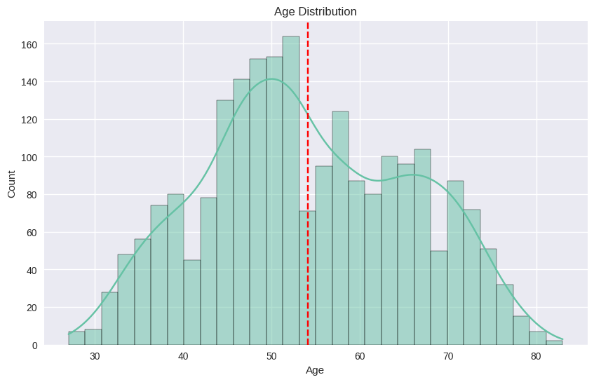

```python
plt.figure()
sns.histplot(data['Age'], bins=30, kde=True)
plt.axvline(data['Age'].mean(), color='red', linestyle='--')
plt.title('Age Distribution')
plt.show()
```

## Income Distribution

#### outlier from dataset made this visual unhelpful

#### added a zoomed in version of the main portion of the data to understand it better

#### placed it in a corner that had no other data, so it wouldn't cover anything

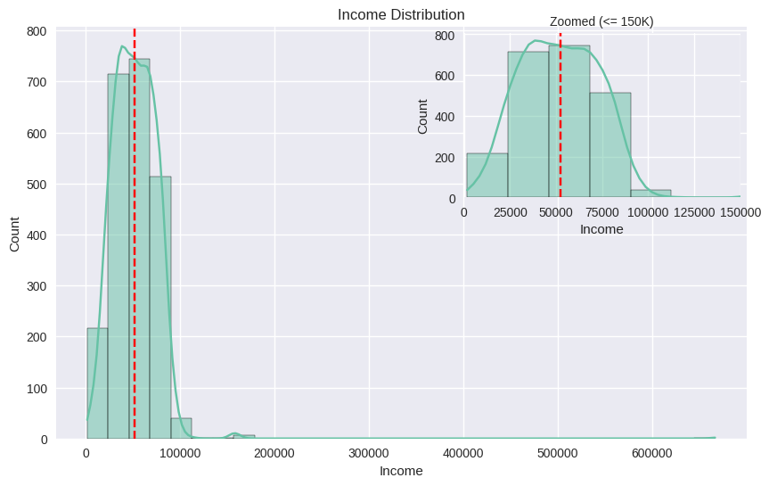

```python
plt.figure()
main_ax = plt.gca()
sns.histplot(data['Income'], bins=30, kde=True, ax=main_ax)
plt.axvline(data['Income'].mean(), color='r', linestyle='--')
plt.title('Income Distribution')

from mpl_toolkits.axes_grid1.inset_locator import inset_axes
ax_inset = inset_axes(main_ax, width="40%", height="40%", loc='upper right')
sns.histplot(data['Income'], bins=30, kde=True, ax=ax_inset)
ax_inset.axvline(data['Income'].mean(), color='r', linestyle='--')
ax_inset.set_xlim(0, 150000)
ax_inset.set_title('Zoomed (<= 150K)', fontsize=10)
plt.show()
```

## Education Distribution

#### Also looked at spending by education level but found stronger patterns with income

#### Considered boxplots for spending variables but bar charts were clearer for presentation

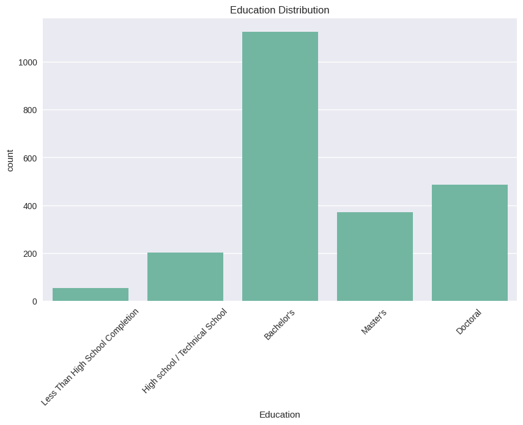

```python
order_edu = ['Less Than High School Completion', 'High school / Technical School', "Bachelor's", "Master's", "Doctoral"]
sns.countplot(data=data, x='Education', order=order_edu)
plt.title('Education Distribution')
plt.xticks(rotation=45)
plt.show()
```

## Marital Status

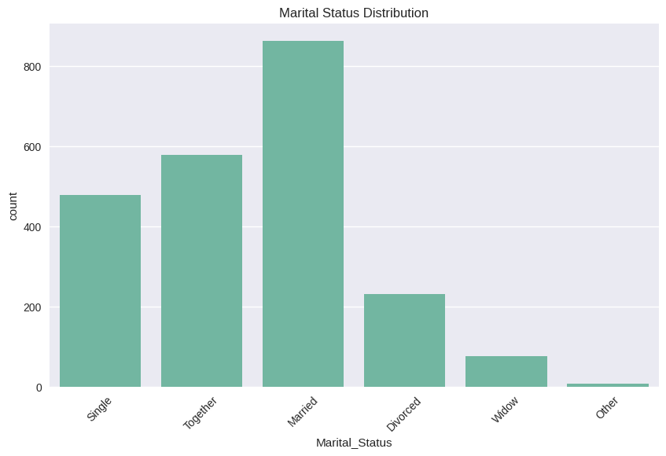

```python
sns.countplot(data=data, x='Marital_Status')
plt.title('Marital Status Distribution')
plt.xticks(rotation=45)
plt.show()
```

## Number of Children per Household

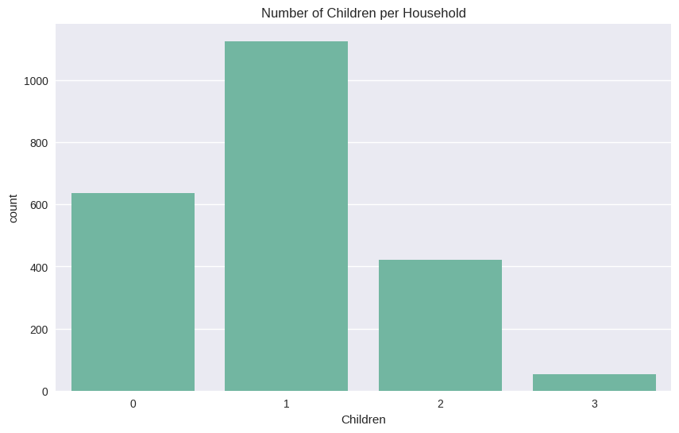

```python
sns.countplot(data=data, x='Children')
plt.title('Number of Children per Household')
plt.show()
```

## Revenue by Product Type

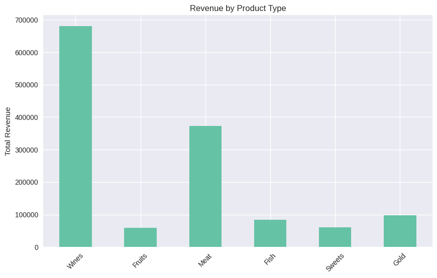

```python
product_cols = ['MntWines', 'MntFruits', 'MntMeatProducts', 'MntFishProducts', 'MntSweetProducts', 'MntGoldProds']
product_labels = ['Wines', 'Fruits', 'Meat', 'Fish', 'Sweets', 'Gold']
data['TotalSpending'] = data[product_cols].sum(axis=1)

plt.figure()
pd.Series(data[product_cols].sum().values, index=product_labels).plot(kind='bar')
plt.title('Revenue by Product Type')
plt.ylabel('Total Revenue')
plt.xticks(rotation=45)
plt.show()
```

## Campaign Acceptance Rates

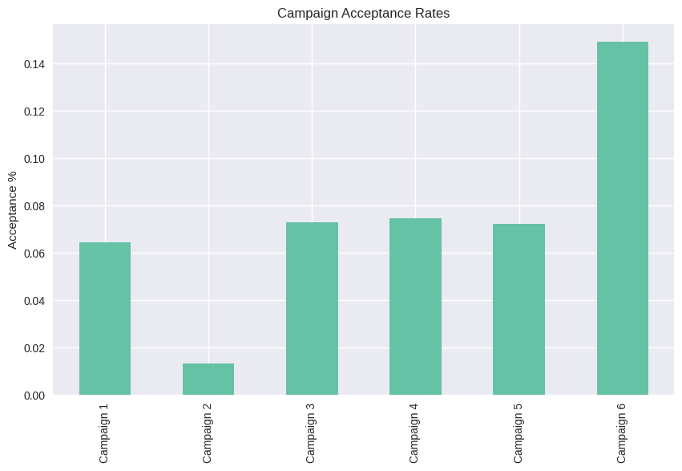

```python
campaign_cols = ['AcceptedCmp1', 'AcceptedCmp2', 'AcceptedCmp3', 'AcceptedCmp4', 'AcceptedCmp5', 'Response']
campaign_labels = ['Campaign 1', 'Campaign 2', 'Campaign 3', 'Campaign 4', 'Campaign 5', 'Campaign 6']
pd.Series(data[campaign_cols].mean().values, index=campaign_labels).plot(kind='bar')
plt.title('Campaign Acceptance Rates')
plt.ylabel('Acceptance %')
plt.show()
```

## Purchase Channels

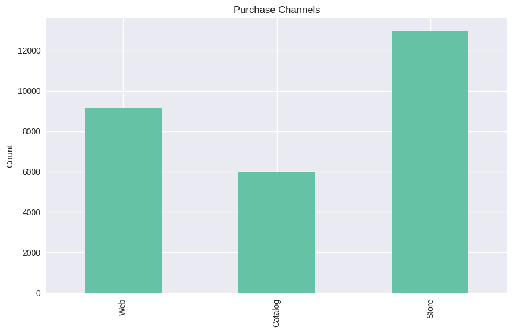

```python
channel_cols = ['NumWebPurchases', 'NumCatalogPurchases', 'NumStorePurchases']
channel_labels = ['Web', 'Catalog', 'Store']
pd.Series(data[channel_cols].sum().values, index=channel_labels).plot(kind='bar')
plt.title('Purchase Channels')
plt.ylabel('Count')
plt.show()
```

## Spending vs. Income

#### outlier from dataset made this visual unhelpful

#### added the zoomed in version below of the main portion of the data to understand it better

#### placed it in a corner that had no other data, so it wouldn't cover anything

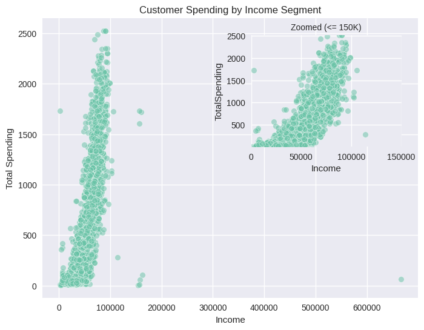

```python
fig, main_ax = plt.subplots(figsize=(8,6))
sns.scatterplot(data=data, x='Income', y='TotalSpending', alpha=0.5, ax=main_ax)
main_ax.set_title('Customer Spending by Income Segment')
main_ax.set_xlabel('Income')
main_ax.set_ylabel('Total Spending')
subset = data[data['Income'] <= 150000]
ax_inset = inset_axes(main_ax, width="40%", height="40%", loc='upper right', borderpad=2)
sns.scatterplot(data=subset, x='Income', y='TotalSpending', alpha=0.5, ax=ax_inset)
ax_inset.set_title('Zoomed (<= 150K)', fontsize=10)
ax_inset.set_xlim(0, 150000)
ax_inset.set_ylim(subset['TotalSpending'].min(), subset['TotalSpending'].max())
plt.show()
```

## Correlation Heatmap

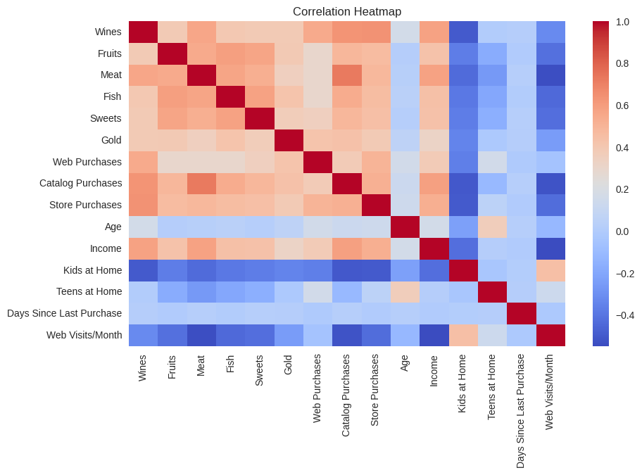

```python
corr_cols = product_cols + channel_cols + ['Age', 'Income', 'Kidhome', 'Teenhome', 'Recency', 'NumWebVisitsMonth']
corr_labels = ['Wines', 'Fruits', 'Meat', 'Fish', 'Sweets', 'Gold', 'Web Purchases', 'Catalog Purchases', 'Store Purchases', 'Age', 'Income', 'Kids at Home', 'Teens at Home', 'Days Since Last Purchase', 'Web Visits/Month']
corr_matrix = data[corr_cols].corr()
sns.heatmap(corr_matrix, cmap='coolwarm', xticklabels=corr_labels, yticklabels=corr_labels)
plt.title('Correlation Heatmap')
plt.show()
```

# Preparing data for clustering

### Had issues with outliers affecting clustering before standardization

### Tried MinMaxScaler first but StandardScaler worked better for this dataset

```python
numeric_cols = data.select_dtypes(include=['int64', 'float64']).columns
scaled = StandardScaler().fit_transform(data[numeric_cols])
```

## Elbow method

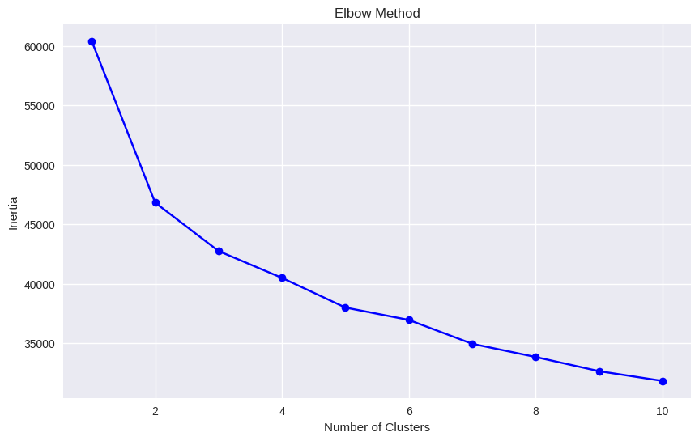

```python
inertia = []
for k in range(1, 11):
    kmeans = KMeans(n_clusters=k, random_state=42)
    kmeans.fit(scaled)
    inertia.append(kmeans.inertia_)

plt.plot(range(1, 11), inertia, 'bo-')
plt.xlabel('Number of Clusters')
plt.ylabel('Inertia')
plt.title('Elbow Method')
plt.show()
```

## Silhouette method

```
k=2: silhouette score = 0.255
k=3: silhouette score = 0.173
k=4: silhouette score = 0.115
k=5: silhouette score = 0.126
k=6: silhouette score = 0.124
k=7: silhouette score = 0.130
k=8: silhouette score = 0.122
k=9: silhouette score = 0.130
k=10: silhouette score = 0.131
```

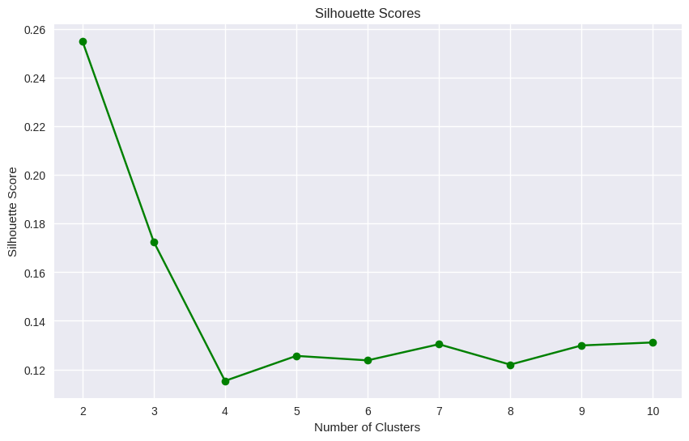

```python
silhouette_scores = []
for k in range(2, 11):
    kmeans = KMeans(n_clusters=k, random_state=42)
    labels = kmeans.fit_predict(scaled)
    score = silhouette_score(scaled, labels)
    silhouette_scores.append(score)
    print(f"k={k}: silhouette score = {score:.3f}")

plt.plot(range(2, 11), silhouette_scores, 'go-')
plt.xlabel('Number of Clusters')
plt.ylabel('Silhouette Score')
plt.title('Silhouette Scores')
plt.show()
```

# KMeans clustering

#### 4 clusters merged too many unique behaviors

#### 6 clusters created segments that weren't meaningfully different for marketing

#### Settled on 5 clusters as optimal for actionable marketing strategies

#### Tried using DBSCAN first, but had trouble finding optimal eps parameter

#### dbscan = DBSCAN(eps=0.5, min_samples=5).fit(scaled)

```python
kmeans = KMeans(n_clusters=5, random_state=42)
data['FinalCluster'] = kmeans.fit_predict(scaled)
```

## Hierarchical clustering

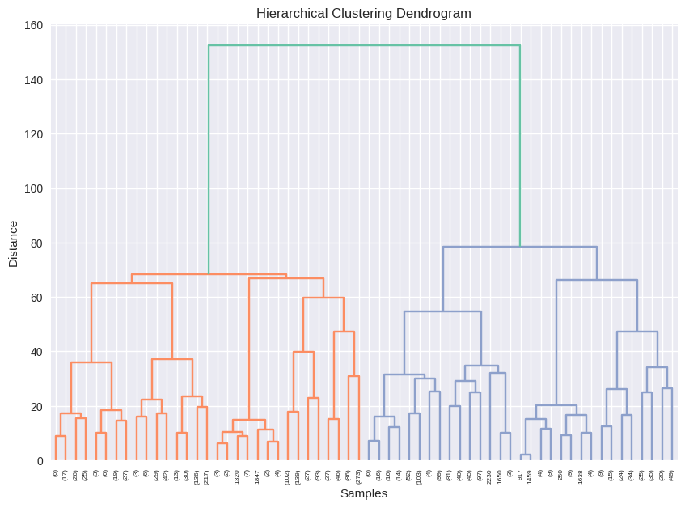

```python
linked = linkage(scaled, method='ward')
plt.figure(figsize=(10, 7))
dendrogram(linked, truncate_mode='level', p=5)
plt.title('Hierarchical Clustering Dendrogram')
plt.xlabel('Samples')
plt.ylabel('Distance')
plt.show()

hierarchical = AgglomerativeClustering(n_clusters=5)
data['HierCluster'] = hierarchical.fit_predict(scaled)
```

## Cluster comparison

```python
ari_score = adjusted_rand_score(data['FinalCluster'], data['HierCluster'])
print(f"Adjusted Rand Index: {ari_score:.3f}")
```

```
Adjusted Rand Index: 0.441
```

## PCA projection

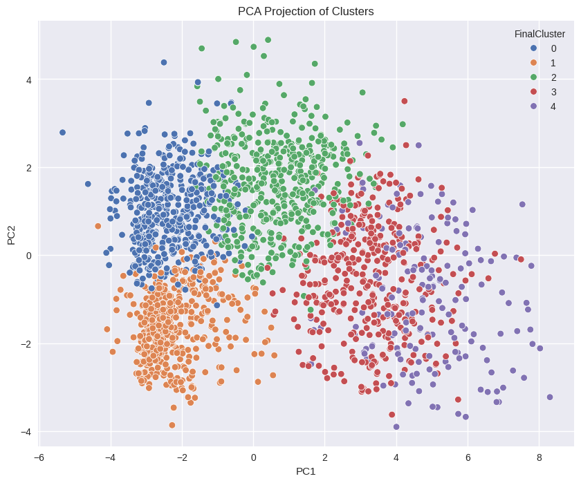

```python
pca = PCA(n_components=2)
pca_result = pca.fit_transform(scaled)
data['PC1'] = pca_result[:, 0]
data['PC2'] = pca_result[:, 1]

plt.figure(figsize=(10, 8))
sns.scatterplot(data=data, x='PC1', y='PC2', hue='FinalCluster', palette='deep')
plt.title('PCA Projection of Clusters')
plt.show()
```

## cluster profiling

```python
cluster_summary = data.groupby('FinalCluster')[['Age', 'Income', 'Children', 'TotalSpending']].mean().round(0)
print("Cluster Summary:")
print(data['FinalCluster'].value_counts().sort_index())
print(cluster_summary)
```

```
Cluster Summary:
FinalCluster
0    523
1    597
2    522
3    413
4    182
Name: count, dtype: int64
               Age   Income  Children  TotalSpending
FinalCluster
0             59.0  42671.0       2.0          124.0
1             45.0  30500.0       1.0          112.0
2             59.0  59183.0       1.0          789.0
3             55.0  74128.0       0.0         1248.0
4             53.0  81311.0       0.0         1625.0
```

# Actionable insights based on cluster profiles

```python
print("Business Insights & Recommendations:")
for idx, row in cluster_summary.iterrows():
    print(f"Cluster {idx}:")
    print(f"- Average Age: {row['Age']} years")
    print(f"- Average Income: ${row['Income']}")
    print(f"- Average Spending: ${row['TotalSpending']}")
    print(f"- Avg. Number of Children: {row['Children']}")

    if row['Income'] > 70000 and row['TotalSpending'] > 1000:
        print("\033[1m  → Target with premium product promotions and loyalty rewards.\033[0m")
        print("    This could help further increase spending from customers who already spend the most.")
    elif row['Income'] < 40000:
        print("\033[1m  → Consider value-based offers and discounts.\033[0m")
        print("    This would help attract and retain more price-sensitive customer segments.")
    elif row['TotalSpending'] > 800:
        print("\033[1m  → Highlight cross-selling opportunities across product categories.\033[0m")
        print("    This could encourage customers to try out more types of products.")
    else:
        print("\033[1m  → Explore re-engagement strategies and web-based marketing.\033[0m")
        print("    Useful for increasing engagement across lower activity customers.")
```

```
Business Insights & Recommendations:
Cluster 0:
- Average Age: 59.0 years
- Average Income: $42671.0
- Average Spending: $124.0
- Avg. Number of Children: 2.0
  → Explore re-engagement strategies and web-based marketing.
    Useful for increasing engagement across lower activity customers.
Cluster 1:
- Average Age: 45.0 years
- Average Income: $30500.0
- Average Spending: $112.0
- Avg. Number of Children: 1.0
  → Consider value-based offers and discounts.
    This would help attract and retain more price-sensitive customer segments.
Cluster 2:
- Average Age: 59.0 years
- Average Income: $59183.0
- Average Spending: $789.0
- Avg. Number of Children: 1.0
  → Explore re-engagement strategies and web-based marketing.
    Useful for increasing engagement across lower activity customers.
Cluster 3:
- Average Age: 55.0 years
- Average Income: $74128.0
- Average Spending: $1248.0
- Avg. Number of Children: 0.0
  → Target with premium product promotions and loyalty rewards.
    This could help further increase spending from customers who already spend the most.
Cluster 4:
- Average Age: 53.0 years
- Average Income: $81311.0
- Average Spending: $1625.0
- Avg. Number of Children: 0.0
  → Target with premium product promotions and loyalty rewards.
    This could help further increase spending from customers who already spend the most.
```

# Further Insights and Actions

#### 1. Wine products dominated spending (especially among higher-income clusters), suggesting potential for premium wine promotions and loyalty programs targeting these specific segments.

#### 2. Dominance of wine sales (especially for higher income clusters) should be further analyzed to understand if this is typical in retail or specific to this dataset.

#### 3. Store purchases remain dominant despite the growth of online shopping, pointing to an opportunity to enhance the in-store experience for key segments identified in this analysis."

#### 4. For future analysis, incorporating seasonal purchasing patterns and customer tenure data would help understand lifetime value potential for each segment.

#### 5. Further exploration could also include segmenting by product preferences or combining this data with customer feedback.

#### 6. Clustering results should be monitored over time to see if customer behavior changes, especially after marketing campaigns.

#### 7. The low campaign response rates (<15%) across all segments indicate a need to revisit campaign messaging and offers - testing personalized promotions based on cluster preferences could improve conversion.

#### 8. Combining this segmentation with A/B testing of marketing messages could provide actionable insights for improving campaign effectiveness across different customer groups.